# BaSiC

Wei Sun

2019-10-02

This R markdown file illustrate the usage of R package `basic` with application on the bulk sample and single cell sequencing data generated by Wang et al. (2014) *Clonal evolution in breast cancer revealed by single nucleus genome sequencing*. Nature, 512(7513), 155-160.

```r
library(basic)
library(ggcorrplot)
library(gridExtra)
```

First read in the somatic mutation calls and read-depth information from bulk tumor and single cells.

```r
load("basic/data/wang_2014.RData")
ls()
```

```
## [1] "asrec"          "mutations.bulk" "mutations.sc"   "trec"
```

```r
dim(mutations.bulk)
```

```
## [1] 789  12
```

```r
mutations.bulk[1:2,]
```

```
##   contig position context ref_allele alt_allele tumor_name normal_name
## 1   chr1  2399526 GCGxCTG          G          A SRR1298936  SRR1163508
## 2   chr1  2406772 GCCxCTG          G          A SRR1298936  SRR1163508
##   t_ref_count t_alt_count failure_reasons judgement totalCN
## 1          43          23              NA      KEEP       2
## 2          54          36              NA      KEEP       2
```

```r
dim(mutations.sc)
```

```
## [1] 789  16
```

```r
mutations.sc[1:2,]
```

```
##              a1 a2 a3 a4 a5 a6 a7 a8 h1 h2 h3 h4 h5 h6 h7 h8
## chr1:2399526 NA  1  1 NA  1 NA  1  0 NA  1 NA NA NA  0 NA  1
## chr1:2406772  1  1  1  0  1 NA  1  1 NA  1 NA NA NA  0 NA  1
```

We have filtered the somatic mutations so that the copy number is either 2 or 1.

```r
table(mutations.bulk$totalCN)
```

```
##
##   1   2
## 185 604
```

Among 789x16 = 12624 entries in the mutation data matrix for the 789 loci and 16 single cells, 4562 ($\sim 36\%$) entries are missing due to low read-depth.

```r
table(c(mutations.sc), useNA="ifany")
```

```
##
##    0    1 <NA>
## 1339 6723 4562
```

```r
table(is.na(mutations.sc))/12624
```

```
##
##     FALSE      TRUE
## 0.6386248 0.3613752
```

To cluster the mutations based on the data from single cells, we first use K-mean clustering.

```r
mutations.sc.naive = mutations.sc
mutations.sc.naive[which(is.na(mutations.sc))] = 0
km = kmeans(mutations.sc.naive, centers=2)

names(km)
```

```
## [1] "cluster"      "centers"      "totss"        "withinss"
## [5] "tot.withinss" "betweenss"    "size"         "iter"
## [9] "ifault"
```

```r
table(km$cluster)
```

```
##
##   1   2
## 339 450
```

Next we cluster the mutations using our method. This involves imputing the missing values in single cell mutation calls. We evaluate the results with number of clusters being 2, 3, or 4. In the following results, `scs$n2` and `scs$n3` indicate results for 2 or 3 clusters, respectively.

```r
scs = cluster.SCS(mutations.sc, asrec, trec, nclust=2:4, verbose=0)

names(scs)
```

```
## [1] "n2"              "n3"              "n4"              "nclust.by.AIC"
## [5] "nclust.by.BIC"   "summary.cluster"
```

```r
scs$summary.cluster
```

```
##    nclust      AIC      BIC nIt
## n2      2 22698.91 22944.54 388
## n3      3 22747.92 23120.09 464
## n4      4 22781.91 23280.62 469
```

```r
scs$n2$theta
```

```
##       alpha1        beta1       alpha2        beta2          pi1
## 6.019844e-13 9.086656e-01 8.021421e-01 9.141878e-01 7.857542e-02
##         rho1          pi2         rho2          pi3         rho3
## 2.643041e-01 4.815755e-01 2.840097e-01 9.760736e-01 1.403657e-01
##         psi1         psi2
## 9.647900e-02 5.270801e-01
```

```r
scs$n3$theta
```

```
##       alpha1        beta1       alpha2        beta2          pi1
## 1.478804e-15 9.088015e-01 8.029482e-01 9.141374e-01 7.857542e-02
##         rho1          pi2         rho2          pi3         rho3
## 2.643041e-01 4.815755e-01 2.840097e-01 9.760736e-01 1.403657e-01
##         psi1         psi2
## 9.647900e-02 5.270801e-01
```

The following codes perform joint analysis of bulk tumor data and single cell data, while accounting for copy number alterations.

```r
b.cn    = mutations.bulk$totalCN
b.asrec = mutations.bulk$t_alt_count
b.trec  = mutations.bulk$t_alt_count + mutations.bulk$t_ref_count

cBSC = cluster.BSC(b.cn, b.asrec, b.trec, mutations.sc, asrec, trec,
                   nclusters=2:4, verbose=0)

names(cBSC)
```

```
## [1] "n2"              "n3"              "n4"              "nclust.by.AIC"
## [5] "nclust.by.BIC"   "summary.cluster"
```

```r
cBSC$summary.cluster
```

```
##    nclust      AIC      BIC nIt
## n2      2 27596.71 27851.85 335
## n3      3 29483.21 29873.42 599
## n4      4 29459.83 29985.11 358
```

As a comparison, we also perform joint analysis of bulk tumor data and single cell data, without accounting for copy number information. To do this, we just set the copy number input to be 2 for all loci.

```r
b.cn  = rep(2, length(b.asrec))
cBSC2 = cluster.BSC(b.cn, b.asrec, b.trec, mutations.sc, asrec, trec,
                    nclusters=2:4, verbose=0)

names(cBSC2)
```

```
## [1] "n2"              "n3"              "n4"              "nclust.by.AIC"
## [5] "nclust.by.BIC"   "summary.cluster"
```

```r
cBSC2$summary.cluster
```

```
##    nclust      AIC      BIC nIt
## n2      2 28104.67 28359.81 819
## n3      3 27339.06 27729.27 421
## n4      4 29142.37 29667.65 327
```

The parameters `nu` is the proportion of mutations that belong to different clusters. The following plots illustrate the cluster means (`gamma`) estimated by different approaches.

```r
scs$n2$nu
```

```
## [1] 0.97591888 0.02408112
```

```r
cBSC$n2$nu
```

```
## [1] 0.97718645 0.02281355
```

```r
cBSC2$n3$nu
```

```
## [1] 0.972116824 0.008871769 0.019011407
```

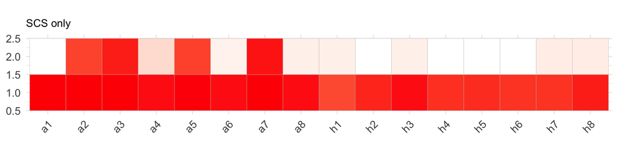

```r
g0 = ggcorrplot(scs$n2$gamma, tl.cex=10, lab = FALSE, show.legend=F) +
  ggtitle('SCS only') + theme(plot.title = element_text(size = 10))

g1 = ggcorrplot(cBSC$n2$gamma, tl.cex=10, lab = FALSE, show.legend=F) +
  ggtitle("BaSiC w/ CNA") + theme(plot.title = element_text(size = 10))

g2 = ggcorrplot(cBSC2$n3$gamma, tl.cex=10, lab = FALSE, show.legend=F) +
  ggtitle("BaSiC w/o CNA") + theme(plot.title = element_text(size = 10))

g3 = ggcorrplot(t(km$centers), tl.cex=10, lab = FALSE, show.legend=F) +
  ggtitle("Kmeans") + theme(plot.title = element_text(size = 10))

g0
```

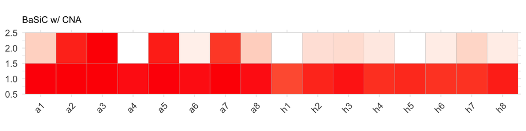

```r
g1
```

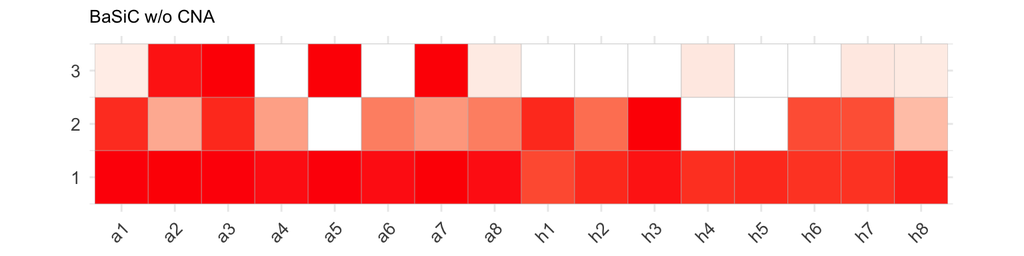

```r
g2
```

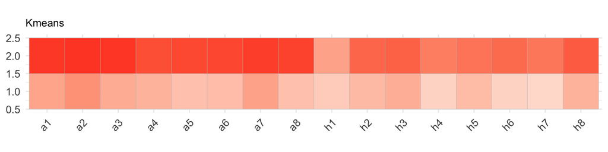

```r
g3
```

Finally, we check mutation classification based on the three approaches.

```r
colSums(scs$n2$postPs)
```

```
## [1] 770  19
```

```r
colSums(cBSC$n2$postPs)
```

```
## [1] 771.00011  17.99989
```

```r
colSums(cBSC2$n3$postPs)
```

```
## [1] 767.000174   6.999826  15.000000
```

```r
mut.scs = apply(scs$n2$postPs, 1, which.max)
mut.bsc = apply(cBSC$n2$postPs, 1, which.max)
mut.bsc.nocn = apply(cBSC2$n3$postPs, 1, which.max)
mut.kmeans = km$cluster

t2 = table(mut.bsc, mut.scs)
t3 = table(mut.bsc, mut.bsc.nocn)
t4 = table(mut.scs, mut.bsc.nocn)
t5 = table(mut.bsc, mut.kmeans)

ts = cbind(t2, t3, t5)
ts
```

```
##     1  2   1 2  3   1   2
## 1 767  4 767 4  0 322 449
## 2   3 15   0 3 15  17   1
```

```r
t4
```

```
##        mut.bsc.nocn
## mut.scs   1   2   3
##       1 763   6   1
##       2   4   1  14
```